# AGEC 936 - Module 1

IV/GMM/Shift-share Design

Jisang Yu  
Kansas State University

# This week

- ([Panel Time Series/Synthetic Control](https://jisangyu-agecon.github.io/AGEC936/Lectures/AGEC936_Synth_Panel_time_series.html))
- Brief overview of Instrumental Variables
- IV in the context of Panel FE set-up
- Panel IV example 1: Bartik/Shift-share IV
- Panel IV example 2: Pre-event trends

# Instrumental Variable

- The “identification” problem

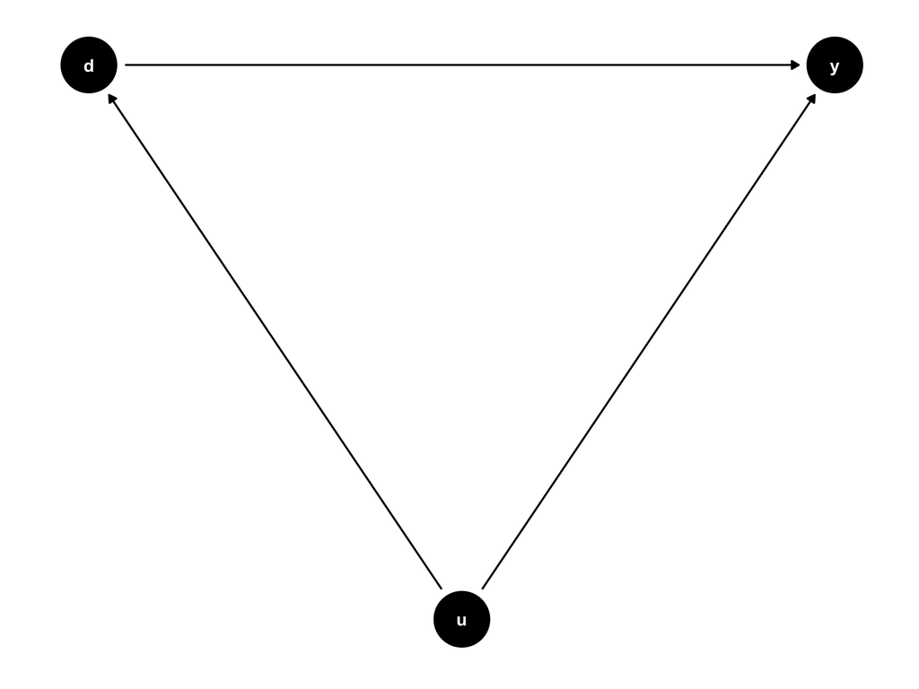

```r
library(dagitty)
library(ggdag)
dag <- dagitty('dag{
                d [pos="0,1"]
                u [pos="1,0"]
                y [pos="2,1"]
                d <- u -> y
                d -> y
               }')
ggdag(dag, layout = "circle") +
  theme_dag()
```

- Solution: Instrumental Variable approach

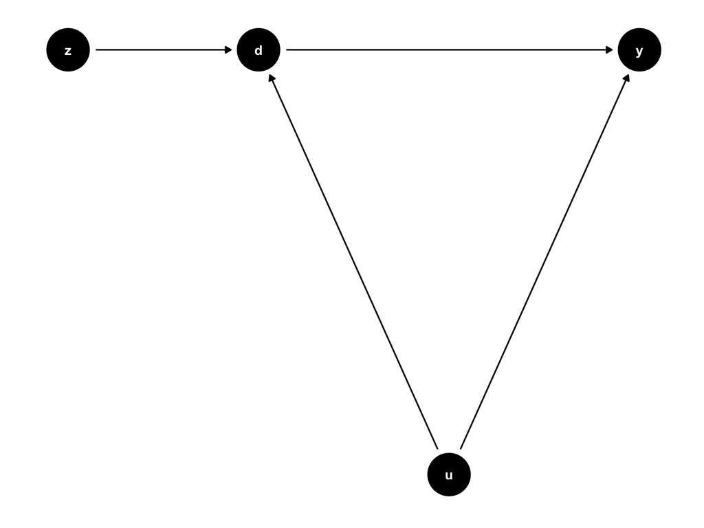

```r
library(dagitty)
library(ggdag)

dag <- dagitty('dag{
                d [pos="1,1"]
                u [pos="2,0"]
                y [pos="3,1"]
                z [pos="0,1"]
                d <- u -> y
                d -> y
                z -> d
               }')
ggdag(dag, layout = "circle") +
  theme_dag()
```

# Basic structure and two key assumptions

$$\begin{align}
y_{i}=\alpha+\rho d_{i}+\epsilon_{i}
\end{align}$$
$$\begin{align}
d_{i}=\beta+\pi z_{i}+\varepsilon_{i}
\end{align}$$

- The (2SLS) instrumental variable estimator is

$$\begin{align}
\hat{\rho}_{iv}=\frac{\sum (z_i - \bar{z})(y_i-\bar{y})}{\sum
(z_i-\bar{z})(d_i - \bar{d})}
\end{align}$$

We can show that
$$\text{plim}
{\rho}_{iv}=\rho.$$

- Similar results for GMM (Efficiency differs based on the error structure).
- Key assumptions
  - The instrument only affects the outcome through the regressor (exclusion restriction):
    $$E(z_i
    \epsilon_i)=0$$
  - The instrument is correlated with the regressor (relevance/strength of the instrument):
    $$Cov(z_i,d_i)\neq
    0$$

# Exclusion Restriction

- It is very difficult to ensure the exclusion restriction.
- Is the randomness in $z$ enough?
- Can we test for the exclusion restriction assumption?
- Exclusion restriction tests when you have many instruments AND at least some valid instruments: See the literature on Mendelian randomization (see Kang et al. (2016), Windmeijer et al. (2019), Goh and Yu (2022)).

# Weak Instruments

Recall that the (2SLS) instrumental variable estimator is

$$\begin{align}
\hat{\rho}_{iv}=\frac{\sum (z_i - \bar{z})(y_i-\bar{y})}{\sum
(z_i-\bar{z})(d_i - \bar{d})}
\end{align}$$

- As $Cov(z_i,d_i)$ becomes zero,$\hat{\rho}_{iv}$ is undefined. Why?
- Can we test for the presence of weak IV? Yes, we can test the null of the coefficients of instruments jointly equal to zero in the first-stage regression. Large F-statistics indicate strong instruments.
- The rule-of-thumb threshold of 10: Recent studies (see Lee et al. (2022)) argue that we need a stronger F-statistics.
- Error structures matter for the reliability of first-stage F-statistics based tests - Need for robust tests: See Olea and Pflueger (2013).

# Heterogeneous Effects and Local Average Treatment Effect

- IV (2SLS/GMM) gives a reliable estimate on the ATE when effects are homogeneous.
- What if the treatment effect is heterogeneous?
  - IV estimate is interpreted as Local Average Treatment Effect (LATE): But it requires monotonicity (e.g., $d_i(z_i=1)>d_i(z_i=0)$)
  - Why is this “Local”?: Identification is based on the subset of the sample.
  - See Angrist, Imbens, and Rubin (1996) on IV and LATE.
  - See Blandhol et al. (2022) on 2SLS and LATE with covariates
- Identification vs External Validity

# Revisiting IV in the context of Panel FE set-up

- Revisiting the identifying assumptions for Panel FE estimator
  $$\begin{align}
  y_{it}=\alpha+\rho d_{it}+v_i + u_{it}
  \end{align}$$
  Within-transformation ($\tilde{k}$ to denote the within transformation) leads to
  $$\begin{align}
  \tilde{y}_{it}=\rho \tilde{d}_{it}+\tilde{u}_{it}
  \end{align}$$
  1. Strict exogeneity: We need $E(\tilde{u}_{it}|\tilde{d}_{it})$. The sufficient condition is $E(u_{it}|d_{i1}, d_{i2},...,d_{iT})=0$.
  2. The regressor, $d_{it}$, needs to vary within each cross-sectional unit over time.
- Revisiting the identifying assumptions for IV estimator (Let’s ignore the panel structure for a moment)
  $$\begin{align}
  y_{i}=\alpha+\rho d_{i}+\varepsilon_{i}
  \end{align}$$
  $$\begin{align}
  d_{i}=\beta+\gamma z_{i}+\eta_{i}
  \end{align}$$
  1. Exclusion restriction: $E(\varepsilon_{i}|z_{i})=0$
  2. Relevancy: $Cov(d_i,z_i) \neq 0$
- Now, let’s think about the identifying assumptions for IV estimator in the context of **Panel FE** model
  $$\begin{align}
  \tilde{y}_{it}=\rho \tilde{d}_{it}+\tilde{u}_{it}
  \end{align}$$
  $$\begin{align}
  \tilde{d}_{it}=\gamma \tilde{z}_{it}+\eta_{it}
  \end{align}$$
  1. Exclusion restriction: We need $E(\tilde{u}_{it}|\tilde{z}_{it})$ or we can represent this condition as $E(z_{it}u_{it}|v_i)=0$. Note that the sufficient condition for this is $E(u_{it}|z_{i1}, z_{i2},...,z_{iT})=0$.
  2. Relevancy: $Cov(\tilde{d}_{it},\tilde{z}_{it}) \neq 0$ or we can write this as $Cov(d_{it},z_{it}|v_i)$ (Necessary to have some **within** variations in $z_{it}$).

# Some considerations

- Consider the following regression equation:
  $$\begin{align}
  y_{it}=\alpha+\rho d_{it}+\varepsilon_{it}
  \end{align}$$
  And you worry that, $Cov(d_{it},\varepsilon_{it}) \neq 0$.
- Using an IV to mitigate this requires $z_{it}$ such that
  $$E(\varepsilon_{it}|z_{it})=0\;\;\text{and}\;\;Cov(z_{it},d_{it}) \neq 0$$
- Recall that with Panel FE approach, we have
  $$\begin{align}
  \tilde{y}_{it}=\rho \tilde{d}_{it}+\tilde{u}_{it}
  \end{align}$$
  meaning that we need $z_{it}$ such that
  $$E(\tilde{u}_{it}|\tilde{z}_{it})=0\;\;\text{and}\;\;Cov(\tilde{z}_{it},\tilde{d}_{it})
  \neq 0$$
- Questions to think about
  1. If we have an instrument that satisfies $E(\varepsilon_{it}|z_{it})=0$, and $Cov(z_{it},d_{it}) \neq 0$, do we need to use Panel FE estimator?
  2. Do we obtain the consistency if we use Panel FE-2SLS with an instrument that satisfies $E(\varepsilon_{it}|z_{it})=0$, and $Cov(z_{it},d_{it}) \neq 0$?

# Some IV/GMM related topics in the context of Panel data applications

- Dynamic panel (Arellano-Bond type estimators)
- Bartik/Shift-share IVs
- Mitigating potential violation of parallel/common pre-event trends

# Panel IV example 1: Bartik/Shift-share IV

- Named after Bartik (1991), also known as “Shift-share” IV.
- The idea is to combine “aggregated/macro-level shocks” and a measure for “heterogeneous (local) exposures” and use this combination as an “instrument”.
- I like the framework of Goldsmith-Pinkham, Sorkin, and Swift (2020), so I will form our discussion around it (two other related papers are Adao, Kolesár, and Morales (2019) and Borusyak, Hull, and Jaravel (2020) – please do check out if you are interested in this literature)
- **Set up**: Consider the following regression equation (now we use subscript $l$ instead of $i$ to emphasize that the unit of observations is at “locality” level):
  $$y_{lt}=\alpha+\beta x_{lt}+v_l+u_{lt}$$
  where the regressor, $x_l$, can be represented as (not necessarily)
  $$x_{lt}=\sum_k z_{lkt} g_{lkt}.$$
  and suppose we have $E(x_{lt}u_{lt}|v_l) \neq 0$. That is, **Panel FE** estimator will not provide a consistent estimate $\hat{\beta}$.
- An example for the variables:
  - $y_{lt}$: Wage in area $l$ in time $t$,
  - $x_{lt}$: Employment growth rate in area $l$ in time $t$,
  - $z_{lkt}$: Employment share of sector $k$ in area $l$ in time $t$,
  - $g_{lkt}$: Growth rate of sector $k$ in area $l$ in time $t$.
- **Bartik Instrument**: It usually takes the following form
  $$B_{lt}=\sum_k z_{lk0} g_{kt},$$
  - $z_{lk0}$: The share of industry/sector $k$ in location $l$ in the base/initial period $0$.
  - $g_{kt}$: The (aggregated) shock to industry/sector $k$ in time $t$. This comes from
    $$g_{lkt}=g_{kt}+\tilde{g}_{lkt}$$
    where $\tilde{g}_{lkt}$ is the idiosyncratic shock/variation.

# A simulation example of a simple Bartik IV

```stata
clear all
set seed 11123

* l=1000
set obs 1000
gen l=_n

* v_l
gen v=runiform(-0.1,0.1)

* k=7 & create initial shares
forval k=1/6{
    gen z`k'=runiform(0,0.13)
}
gen z7=1-z1-z2-z3-z4-z5-z6

* t=10
expand 10
bys l: gen t=_n

* change shares as time evolves
forval k=1/6{
    replace z`k'=z`k'*(1+t*0.1*runiform(0,0.2)) if t>1
}
replace z7=1-z1-z2-z3-z4-z5-z6 if t>1

* growth rates at kt
forval k=1/7{
gen g`k'=1+runiform(-0.2,0.2)
}

* growth rate at lkt
forval k=1/7{
gen latent_l`k'=runiform(0,0.25)
gen gl`k'=g`k'*(1+latent_l`k')+1.5*v
}

* x at lkt
forval k=1/7{
gen x`k'=gl`k'*z`k'
}
gen x=x1+x2+x3+x4+x5+x6+x7

* DGP: y at lkt
gen y=2+3*x+(latent_l1+latent_l2+latent_l3+latent_l4+latent_l5+latent_l6+latent_l7)+0.5*v+rnormal()

* OLS
reg y x, robust

* FE
xtset l t
xtreg y x, fe robust

* FE2SLS Bartik
* Bartik instrument
* create initial share variable
gen initial=0
replace initial=1 if t==1
forval k=1/7{
gen tempz`k'=initial*z`k'
bys l: gen z0`k'=sum(tempz`k')
}
* Bartik instrument
forval k=1/7{
gen bartik`k'=z0`k'*g`k'
}
gen bartik=bartik1+bartik2+bartik3+bartik4+bartik5+bartik6+bartik7
* FE 2SLS
xtivreg2 y (x=bartik), fe robust first
```

```
Number of observations (_N) was 0, now 1,000.





(9,000 observations created)


(9,000 real changes made)
(9,000 real changes made)
(9,000 real changes made)
(9,000 real changes made)
(9,000 real changes made)
(9,000 real changes made)

(9,000 real changes made)







Linear regression                               Number of obs     =     10,000
                                                F(1, 9998)        =    1972.95
                                                Prob > F          =     0.0000
                                                R-squared         =     0.1641
                                                Root MSE          =      1.015

------------------------------------------------------------------------------
             |               Robust
           y | Coefficient  std. err.      t    P>|t|     [95% conf. interval]
-------------+----------------------------------------------------------------
           x |   3.556282   .0800642    44.42   0.000      3.39934    3.713223
       _cons |   2.249347   .0908451    24.76   0.000     2.071272    2.427422
------------------------------------------------------------------------------


Panel variable: l (strongly balanced)
```

[output cut: 143 more lines]

```
Weak identification test (Cragg-Donald Wald F statistic):              2.8e+04
                         (Kleibergen-Paap rk Wald F statistic):        2.6e+04
Stock-Yogo weak ID test critical values: 10% maximal IV size             16.38
                                         15% maximal IV size              8.96
                                         20% maximal IV size              6.66
                                         25% maximal IV size              5.53
Source: Stock-Yogo (2005).  Reproduced by permission.
NB: Critical values are for Cragg-Donald F statistic and i.i.d. errors.
------------------------------------------------------------------------------
Hansen J statistic (overidentification test of all instruments):         0.000
                                                 (equation exactly identified)
------------------------------------------------------------------------------
Instrumented:         x
Excluded instruments: bartik
------------------------------------------------------------------------------
```

# Identifying assumptions

- Recall that the (second-stage) regression equation is
  $$y_{lt}=\alpha+\beta x_{lt}+v_l+u_{lt}$$
  and the Bartik Instrument is
  $$B_{lt}=\sum_k z_{lk0} g_{kt},$$
- Identifying assumptions for FE2SLS
  - Exclusion restriction
    $$E(B_{lt}u_{lt}|v_l)=0$$
  - Relevance
    $$Cov(x_{lt},B_{lt}|v_l) \neq 0$$
- Let’s be more specific. The FE2SLS estimator with the Bartik instrument is (Goldsmith-Pinkham, Sorkin, and Swift 2020; Borusyak, Hull, and Jaravel 2020)
  $$\hat{\beta}_{Bartik}=\frac{\sum_l \sum_t \sum_k
  z_{lk0}g_{kt}\tilde{y}_{lt}}{\sum_l \sum_t \sum_k
  z_{lk0}g_{kt}\tilde{x}_{lt}}$$
  where $\tilde{k}$ is the residual of regress $k$ on $v_l$ (or any possible other covariates).
- This leads to
  $$\hat{\beta}_{Bartik}-\beta=\frac{\sum_l \sum_t \sum_k
  z_{lk0}g_{kt}\tilde{u}_{lt}}{\sum_l \sum_t \sum_k
  z_{lk0}g_{kt}\tilde{x}_{lt}} \\
  =\frac{\sum_t \sum_k g_{kt} \sum_l z_{lk0} \tilde{u}_{lt}}{\sum_t \sum_k
  g_{kt} \sum_l z_{lk0} \tilde{x}_{lt}}$$
  - $L$ consistency: $E(z_{lk0} \tilde{u}_{lt})=0$ (Focus of Goldsmith-Pinkham, Sorkin, and Swift (2020))
  - $K$ consistency: $E( g_{kt} \eta_{kt})=0$ where $\eta_{kt}=\sum_l z_{lk0} \tilde{u}_{lt}$.

# Decomposition and Rotemberg weights

- Goldsmith-Pinkham, Sorkin, and Swift (2020) shows the following (I am presenting the version of their representation in Panel data set-up):
  $$\hat{\beta}_{Bartik}=\sum_k \sum_s \hat{\alpha}_{ks} \hat{\beta}_{ks}$$
  where
  $$\hat{\beta}_{ks}=\frac{\sum_l \sum_t z_{lk0} \times
  \mathbb{1}_{t}(t=s)\tilde{y}_{lt}}{\sum_l \sum_t z_{lk0} \times
  \mathbb{1}_{t}(t=s)\tilde{x}_{lt}}$$
  and
  $$\hat{\alpha}_{ks}=\frac{\sum_l \sum_t g_{kt} z_{lk0} \times
  \mathbb{1}_{t}(t=s)\tilde{x}_{lt}}{\sum_k \sum_l \sum_t g_{kt} z_{lk0}
  \times \mathbb{1}_{t}(t=s)\tilde{x}_{lt}}.$$
  (This is the Goldsmith-Pinkham, Sorkin, and Swift (2020) decomposition based on Rotemberg weights)
- Interpretation of the decomposition: $\hat{\beta}_{ks}$ is an IV estimate that uses $z_{lk0} \times \mathbb{1}_{t}(t=s)$ as an instrument.
- Implications of the weight $\hat{\alpha}_{ks}$: If $\hat{\beta}_{ks}$ is biased (potentially, due to the misspecified moment condition), $\hat{\alpha}_{ks}$ represents how much of this bias translates to the overall bias.

# Approaches to test for identifying assumptions

- Check the correlations between initial characteristics and initial shares, $z_{lk0}$: Visualize the source of variation, and potentially can control for the characteristics that is correlated with the shares (the correlated initial characteristic times time dummies).
- Testing for pre-trends.
- Use many instruments (e.g. $z_{lk0} \times \mathbb{1}_{t}(t=s)$) and compare or do over-identification test.

# Pre-event trends: Going back to the parallel/common trend assumption

- Motivation: What if the parallel/common trend assumption falls apart?
- One way is to control for observables – conditional parallel/common trend (e.g. Callaway and Sant’Anna 2020).
- Denote $y$ as the outcome, $d$ as the treatment, $x$ as the observable control, and $w$ as the unobservable confounder (assume the within transformation). Here is my attempt on drawing DAG for this problem (Full disclosure – I am as new to DAG as you are so this needs some verification):

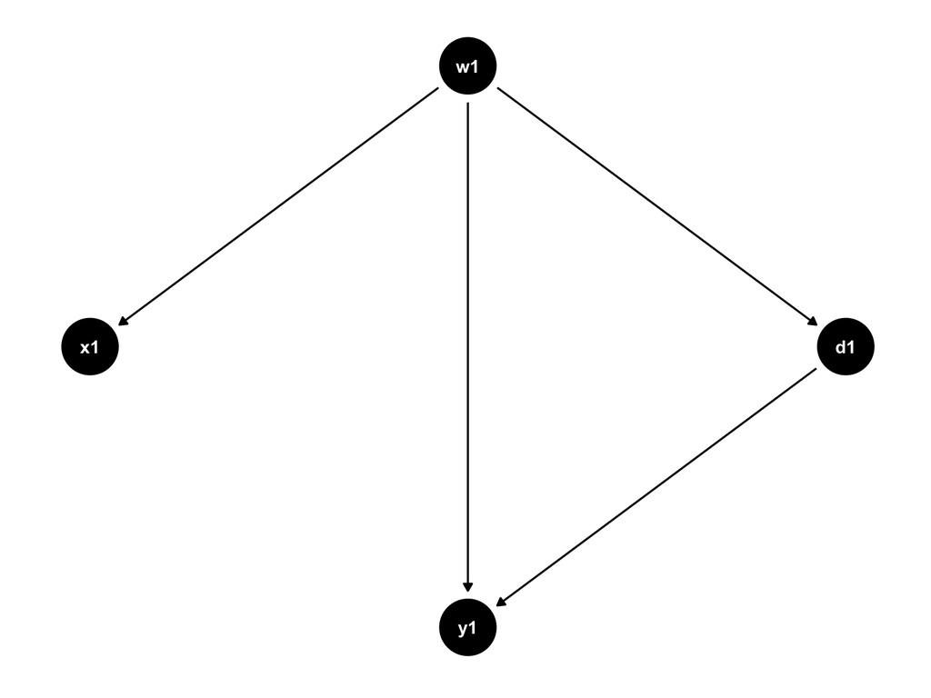

```r
library(dagitty)
library(ggdag)

dag <- dagitty("dag{y1 <- w1 -> d1
                d1 -> y1
                w1 -> x1
               }")
ggdag(dag, layout = "circle") +
  theme_dag()
```

# Panel IV example 2: Pre-event trends (Freyaldenhoven, Hansen, and Shapiro 2019)

- Again, an attempt to draw a DAG to show the IV approach can work:

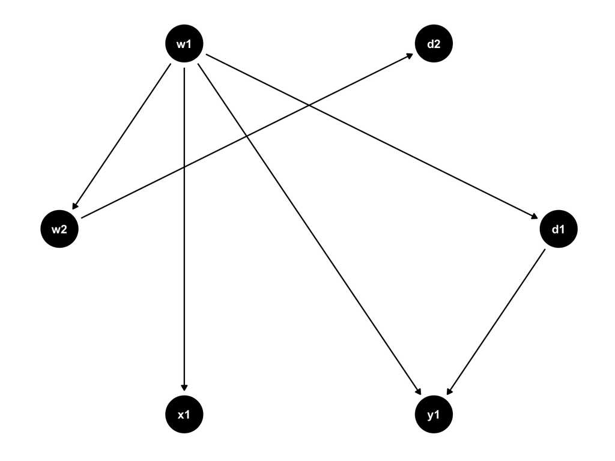

```r
library(dagitty)
library(ggdag)

dag <- dagitty("dag{y1 <- w1 -> d1
                d1 -> y1
                w1 -> x1
                w1 -> w2
                w2 -> d2
               }")
ggdag(dag, layout = "circle") +
  theme_dag()
```

- Obviously, using the observable control is fine if the observable $x$ **perfectly** explains the unobservable confounder, $w$. If not, we have so-called **regression dilution/measurement error** bias.
- The **key** idea of Freyaldenhoven, Hansen, and Shapiro (2019): Use the **lead(s)** of the treatment variable as **instruments**.
- Practically, one can do the following (again, all variables are within transformed): regress $y$ on $d$ and $x$ but **instrument** $x$ using the **leads** of $d$.

# A mini-version simulation of Freyaldenhoven, Hansen, and Shapiro (2019): Pre-trend

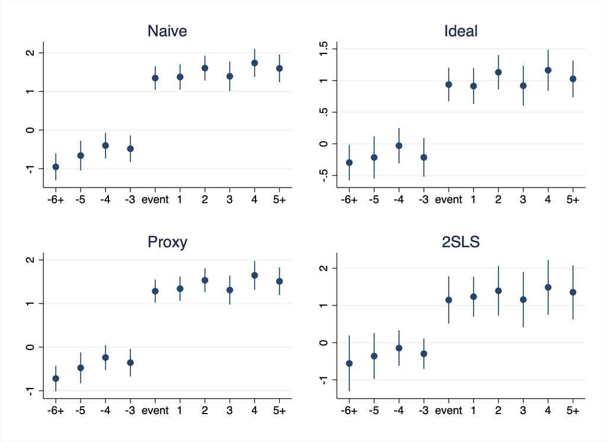

```stata
clear
set seed 11123
set obs 500

egen id = seq()
bys id: gen alpha = rnormal(0,1)
expand 20
sort id
by id: gen year=_n
xtset id year

*create eta
bys id: gen eta=0 if _n==1
bys id: replace eta=eta[_n-1]+rnormal(0,1) if _n>1
*create x
bys id: gen x = eta + rnormal(0,2)
*create z
bys id: gen dtemp = eta
bys id: gen d = (dtemp >4)
bys id: replace d=1 if d[_n-1]==1
drop dtemp

*create y
bys id: gen y = d + .25*eta + .2*year + alpha + rnormal(0,1)

*create dummmies for time period of event and pre/post
bys id: gen event = d-d[_n-1]
recode event (.=0)
foreach n of num 1(1)5{
  bys id: gen t_`n'=event[_n+`n']
  bys id: gen t`n'=event[_n-`n']
}
recode t* (.=0)

*create instruments
foreach n of num 1(1)5 {
  bys id: gen d_lead`n'=F`n'.d
  bys id: replace d_lead`n'=1 if d_lead`n'[_n-1]==1
}
recode d* (.=0)

*Add dummies for both sides of eventplot
bys id: gen t_6=-d_lead5
bys id: replace t5=1 if t5[_n-1]==1
recode t5 (.=0)

*labeling for figures
label var t_6 "-6+"
label var t_5 "-5"
label var t_4 "-4"
label var t_3 "-3"
label var t_2 "-2"
label var t_1 "-1"
label var t1 "1"
label var t2 "2"
label var t3 "3"
label var t4 "4"
label var t5 "5+"

*keep sample with enough lead and lag
keep if year>6 & year<16
*pre-trends comparison
areg y t_6 t_5 t_4 t_3 t_2 event t1 t2 t3 t4 t5 i.year, absorb(id) vce(cluster id)
coefplot, keep(t_6 t_5 t_4 t_3 event t1 t2 t3 t4 t5) vertical graphregion(color(white)) title("Naive") saving(nocontrol.gph, replace)

areg y t_6 t_5 t_4 t_3 event t1 t2 t3 t4 t5 eta i.year, absorb(id) vce(cluster id)
coefplot, keep(t_6 t_5 t_4 t_3 event t1 t2 t3 t4 t5) vertical graphregion(color(white)) title("Ideal") saving(eta.gph, replace)

areg y t_6 t_5 t_4 t_3 event t1 t2 t3 t4 t5 x i.year, absorb(id) vce(cluster id)
coefplot, keep(t_6 t_5 t_4 t_3 event t1 t2 t3 t4 t5) vertical graphregion(color(white)) title("Proxy") saving(proxy.gph, replace)

xi: xtivreg2 y t_6 t_5 t_4 t_3 event t1 t2 t3 t4 t5 (x=d_lead1) i.year, fe cluster(id)
coefplot, keep(t_6 t_5 t_4 t_3 event t1 t2 t3 t4 t5) vertical graphregion(color(white)) title("2SLS") saving(panel2sls.gph, replace)

graph combine nocontrol.gph eta.gph proxy.gph panel2sls.gph, col(2) graphregion(color(white))
graph export preevent_trend.png, replace

rm nocontrol.gph
rm eta.gph
rm proxy.gph
rm panel2sls.gph
```

# A mini-version simulation of Freyaldenhoven, Hansen, and Shapiro (2019): ATE

```stata
*Not mitigating non-parallel trend
areg y d i.year, absorb(id) vce(cluster id)
*FE2SLS
xi: xtivreg2 y d (x=d_lead1) i.year, fe cluster(id)
```

```
command coefplot is unrecognized
r(199);



Linear regression, absorbing indicators             Number of obs     =  4,500
Absorbed variable: id                               No. of categories =    500
                                                    F(9, 499)         = 136.26
                                                    Prob > F          = 0.0000
                                                    R-squared         = 0.6979
                                                    Adj R-squared     = 0.6594
                                                    Root MSE          = 1.0479

                                   (Std. err. adjusted for 500 clusters in id)
------------------------------------------------------------------------------
             |               Robust
           y | Coefficient  std. err.      t    P>|t|     [95% conf. interval]
-------------+----------------------------------------------------------------
           d |   1.678971    .098881    16.98   0.000     1.484697    1.873246
        year |
          8  |   .1992058   .0686899     2.90   0.004     .0642489    .3341628
          9  |   .3380996   .0692132     4.88   0.000     .2021143    .4740849
         10  |   .5980075   .0696946     8.58   0.000     .4610764    .7349385
         11  |   .8058226   .0721737    11.17   0.000     .6640208    .9476244
         12  |   .8943974   .0715926    12.49   0.000     .7537373    1.035057
         13  |   1.039585   .0776219    13.39   0.000     .8870789    1.192091
         14  |   1.300039   .0747294    17.40   0.000     1.153216    1.446862
         15  |   1.508567   .0732636    20.59   0.000     1.364624     1.65251
       _cons |   1.399976   .0494024    28.34   0.000     1.302913    1.497038
------------------------------------------------------------------------------

i.year            _Iyear_7-15         (naturally coded; _Iyear_7 omitted)

FIXED EFFECTS ESTIMATION
------------------------
Number of groups =       500                    Obs per group: min =         9
                                                               avg =       9.0
                                                               max =         9

IV (2SLS) estimation
```

[output cut: 32 more lines]

```
Stock-Yogo weak ID test critical values: 10% maximal IV size             16.38
                                         15% maximal IV size              8.96
                                         20% maximal IV size              6.66
                                         25% maximal IV size              5.53
Source: Stock-Yogo (2005).  Reproduced by permission.
NB: Critical values are for Cragg-Donald F statistic and i.i.d. errors.
------------------------------------------------------------------------------
Hansen J statistic (overidentification test of all instruments):         0.000
                                                 (equation exactly identified)
------------------------------------------------------------------------------
Instrumented:         x
Included instruments: d _Iyear_8 _Iyear_9 _Iyear_10 _Iyear_11 _Iyear_12
                      _Iyear_13 _Iyear_14 _Iyear_15
Excluded instruments: d_lead1
------------------------------------------------------------------------------
```

# What else…?

- Survey: [Click here](https://kstate.qualtrics.com/jfe/form/SV_0cXZVbMH9TBeOTI)
- Questions/comments?

# References

Adao, Rodrigo, Michal Kolesár, and Eduardo Morales. 2019. “Shift-Share Designs: Theory and Inference.” *The Quarterly Journal of Economics* 134 (4): 1949–2010.

Angrist, Joshua D, Guido W Imbens, and Donald B Rubin. 1996. “Identification of Causal Effects Using Instrumental Variables.” *Journal of the American Statistical Association* 91 (434): 444–55.

Bartik, Timothy J. 1991. “Who Benefits from State and Local Economic Development Policies?”

Blandhol, Christine, John Bonney, Magne Mogstad, and Alexander Torgovitsky. 2022. “When Is TSLS Actually Late?” National Bureau of Economic Research.

Borusyak, Kirill, Peter Hull, and Xavier Jaravel. 2020. “Quasi-Experimental Shift-Share Research Designs.”

Callaway, Brantly, and Pedro HC Sant’Anna. 2020. “Difference-in-Differences with Multiple Time Periods.” *Journal of Econometrics*.

Freyaldenhoven, Simon, Christian Hansen, and Jesse M Shapiro. 2019. “Pre-Event Trends in the Panel Event-Study Design.” *American Economic Review* 109 (9): 3307–38.

Goh, Gyuhyeong, and Jisang Yu. 2022. “Causal Inference with Some Invalid Instrumental Variables: A Quasi-Bayesian Approach.” *Oxford Bulletin of Economics and Statistics* 84 (6): 1432–51.

Goldsmith-Pinkham, Paul, Isaac Sorkin, and Henry Swift. 2020. “Bartik Instruments: What, When, Why, and How.” *American Economic Review* 110 (8): 2586–2624.

Kang, Hyunseung, Anru Zhang, T Tony Cai, and Dylan S Small. 2016. “Instrumental Variables Estimation with Some Invalid Instruments and Its Application to Mendelian Randomization.” *Journal of the American Statistical Association* 111 (513): 132–44.

Lee, David S, Justin McCrary, Marcelo J Moreira, and Jack Porter. 2022. “Valid t-Ratio Inference for IV.” *American Economic Review* 112 (10): 3260–90.

Olea, José Luis Montiel, and Carolin Pflueger. 2013. “A Robust Test for Weak Instruments.” *Journal of Business & Economic Statistics* 31 (3): 358–69.

Windmeijer, Frank, Helmut Farbmacher, Neil Davies, and George Davey Smith. 2019. “On the Use of the Lasso for Instrumental Variables Estimation with Some Invalid Instruments.” *Journal of the American Statistical Association* 114 (527): 1339–50.